# Everything Starts with Data Homework 4

Ayush Agarwal

## Problem 1

For this problem, you will evaluate the redwine.txt dataset. For 1599 variants of red wine, it contains 1 response variable, wine quality (QA), and 11 explanatory variables: fixed acidity (FA), volatile acidity (VA), citric acid (CA), residual sugar (RS), chlorides (CH), free sulfur dioxide (FS), total sulfur dioxide (SD), density (DE), pH (PH), sulphates (SU), and alcohol (AL). Note: some variables contain missing values, you will handle them in Problem 2; for now, you may ignore them.

This dataset comes from the UCI repository: https://archive.ics.uci.edu/ml/datasets/wine+quality

Note: you must include all plots, either in the body of your assignment solutions or as an appendix.

```r
df = read.table('redwine.txt', header=TRUE)
df <- na.omit(df)
head(df)
```

```
##   QA   FA   VA   CA  RS    CH FS SD     DE   PH   SU  AL
## 1  5  7.4 0.70 0.00 1.9 0.076 11 34 0.9978 3.51 0.56 9.4
## 2  5  7.8 0.88 0.00 2.6 0.098 25 67 0.9968 3.20 0.68 9.8
## 3  5  7.8 0.76 0.04 2.3 0.092 15 54 0.9970 3.26 0.65 9.8
## 4  6 11.2 0.28 0.56 1.9 0.075 17 60 0.9980 3.16 0.58 9.8
## 5  5  7.4 0.70 0.00 1.9 0.076 11 34 0.9978 3.51 0.56 9.4
## 6  5  7.4 0.66 0.00 1.8 0.075 13 40 0.9978 3.51 0.56 9.4
```

### Problem 1a

For each of the 12 variables, plot the distribution using either a histogram or stem-and-leaf plot, whichever you deem more appropriate (for each variable).

#### Explanation

Using Stem and leaf plot for integer data type variables while using histogram to visualise continuous numeric variables. Histogram gives better visualization and readibility for continuous variables. Stem and leaf plot works fine when number of categories are less and easier to visualize. Upon increasing more and more classes, it becomes harder to read stem and leaf plot

```r
for (column_name in colnames(df)) {
  unique_count <- length(unique(df[[column_name]]))
  data_type <- class(df[[column_name]])
  cat("Column Name:", column_name, "\n")
  cat("Unique Values Count:", unique_count, "\n")
  cat("Data Type:", data_type, "\n")
  cat("\n")
}
```

```
## Column Name: QA
## Unique Values Count: 6
## Data Type: integer
##
## Column Name: FA
## Unique Values Count: 96
## Data Type: numeric
##
## Column Name: VA
## Unique Values Count: 143
## Data Type: numeric
##
## Column Name: CA
## Unique Values Count: 80
## Data Type: numeric
##
## Column Name: RS
## Unique Values Count: 91
## Data Type: numeric
##
## Column Name: CH
## Unique Values Count: 151
## Data Type: numeric
##
## Column Name: FS
## Unique Values Count: 59
## Data Type: numeric
##
## Column Name: SD
## Unique Values Count: 141
## Data Type: numeric
##
## Column Name: DE
## Unique Values Count: 431
## Data Type: numeric
##
## Column Name: PH
## Unique Values Count: 103
## Data Type: numeric
##
## Column Name: SU
## Unique Values Count: 95
## Data Type: numeric
##
## Column Name: AL
## Unique Values Count: 65
## Data Type: numeric
```

```
## Stem-and-Leaf Plot for QA :
##
##   The decimal point is at the |
##
##   3 | 0000000000
##   3 |
##   4 | 0000000000000000000000000000000000000000000000000000
##   4 |
##   5 | 00000000000000000000000000000000000000000000000000000000000000000000+585
##   5 |
##   6 | 00000000000000000000000000000000000000000000000000000000000000000000+540
##   6 |
##   7 | 00000000000000000000000000000000000000000000000000000000000000000000+116
##   7 |
##   8 | 00000000000000000
```

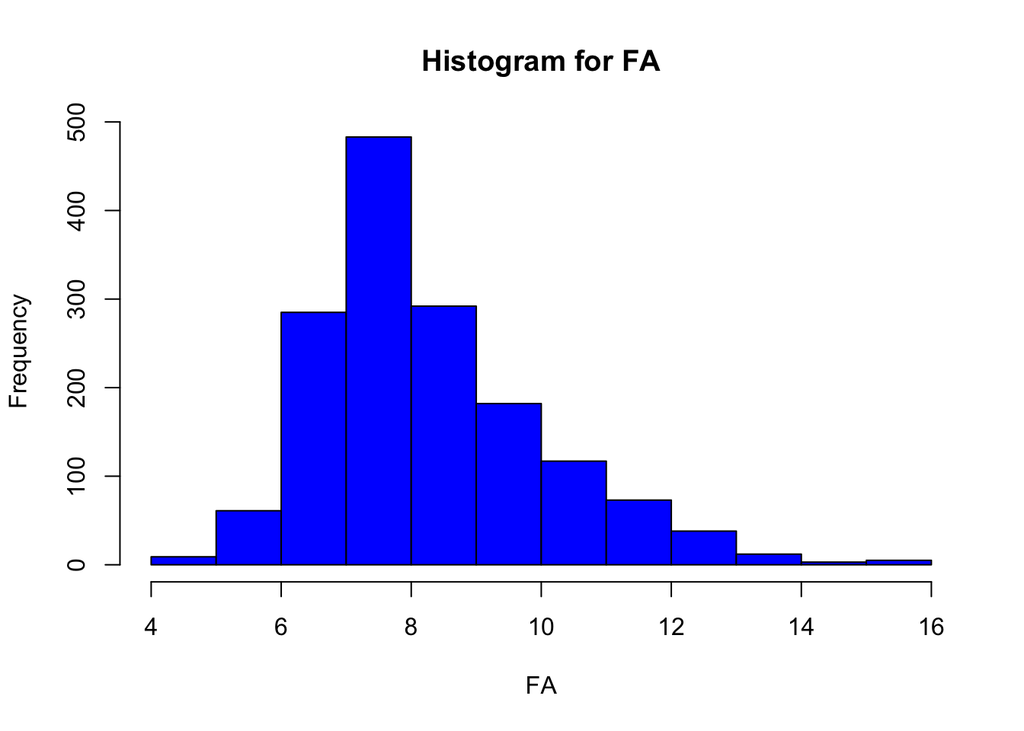

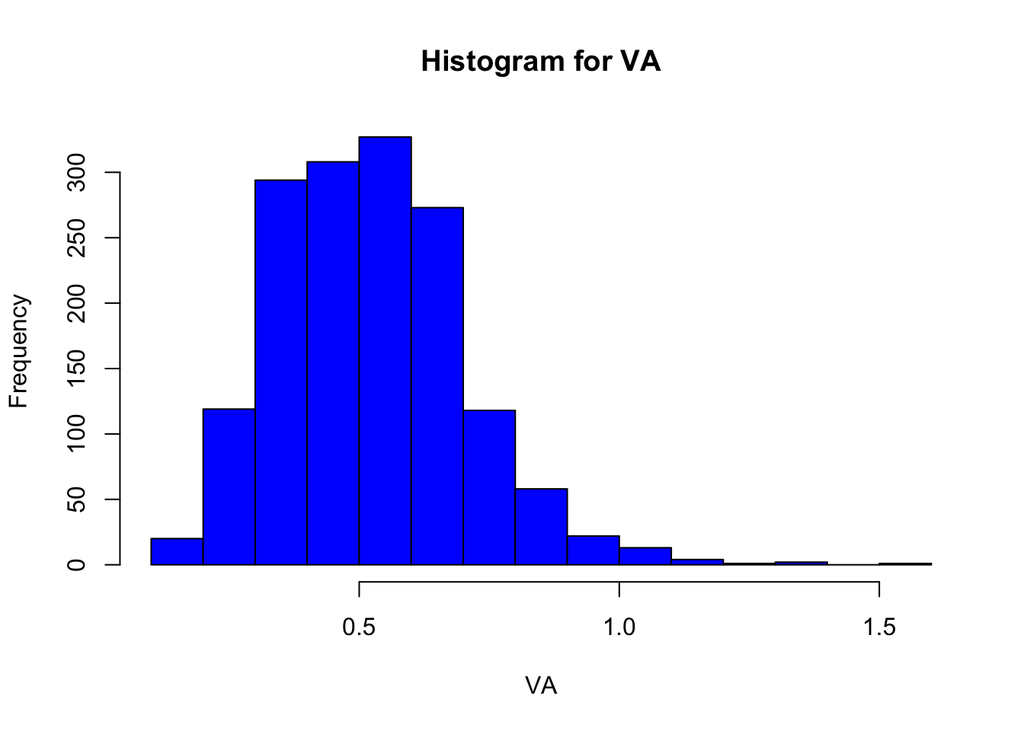

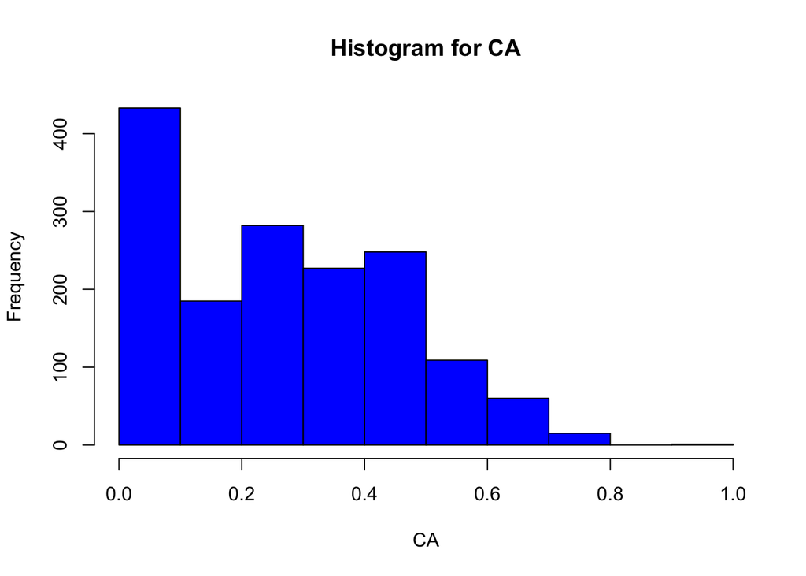

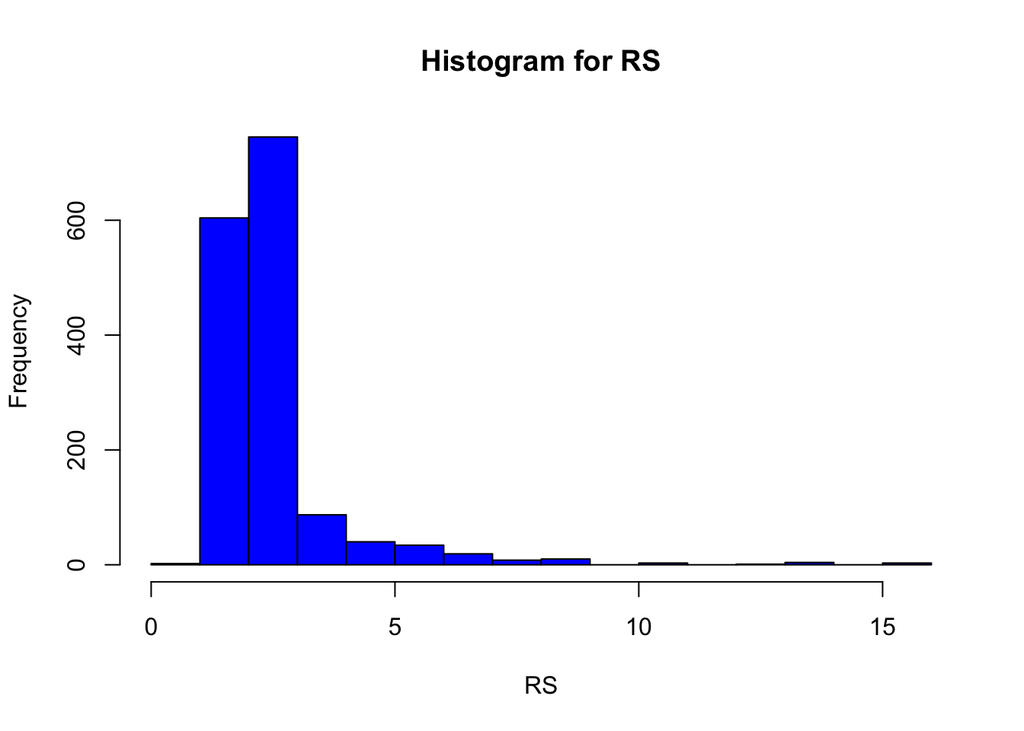

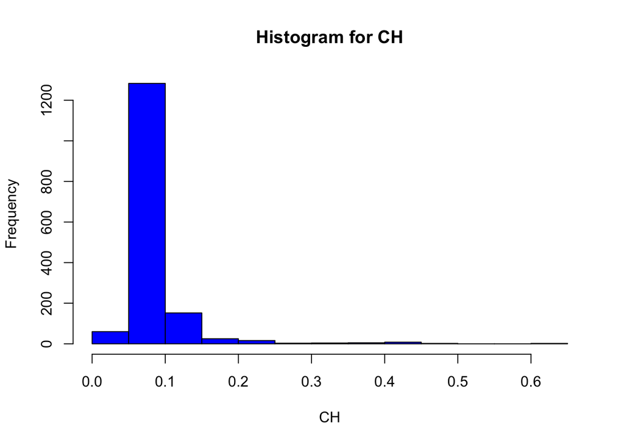

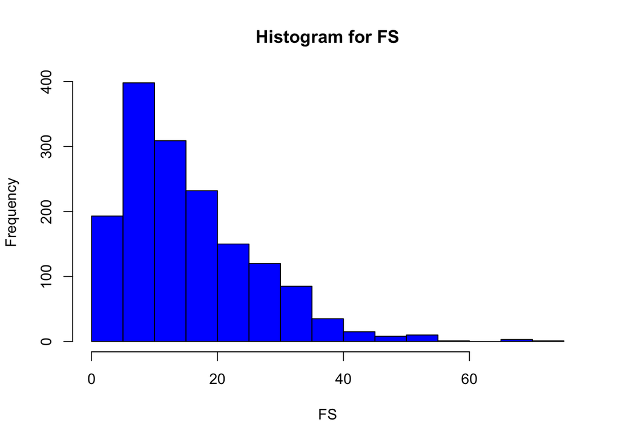

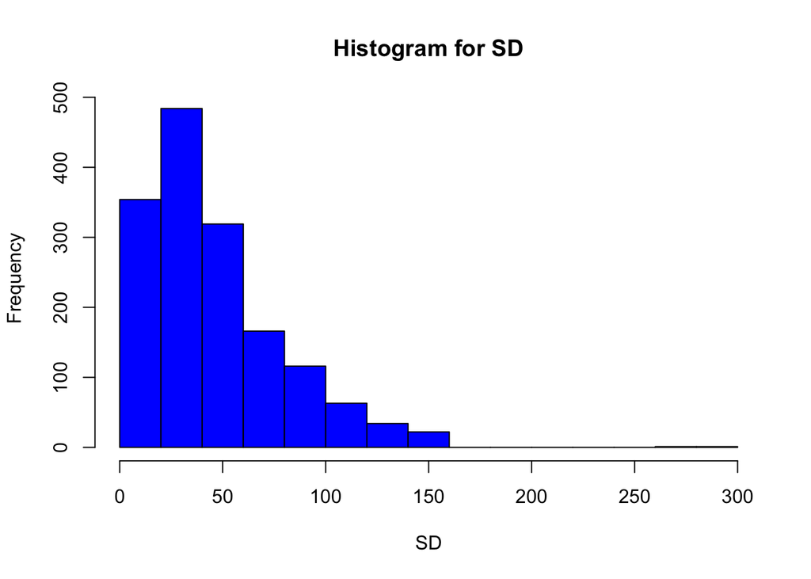

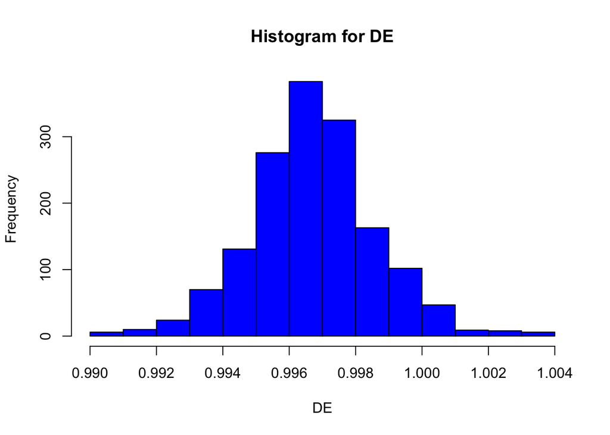

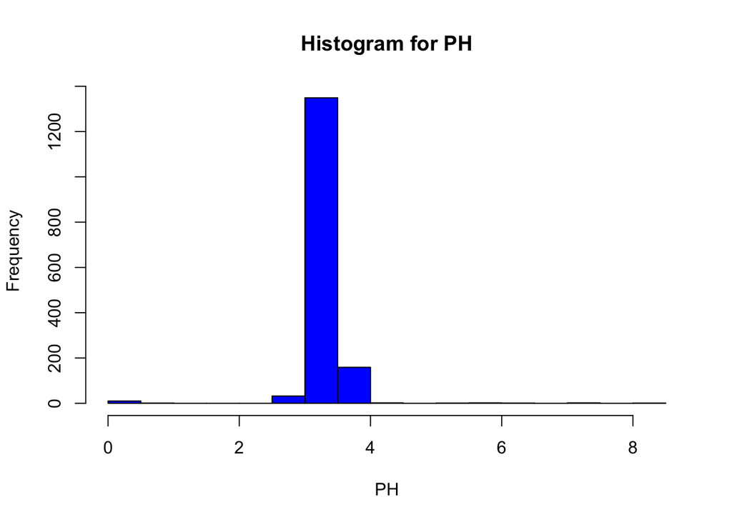

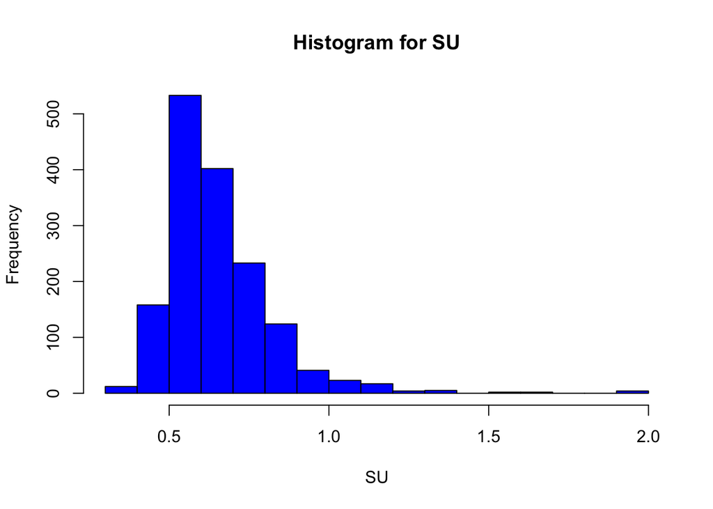

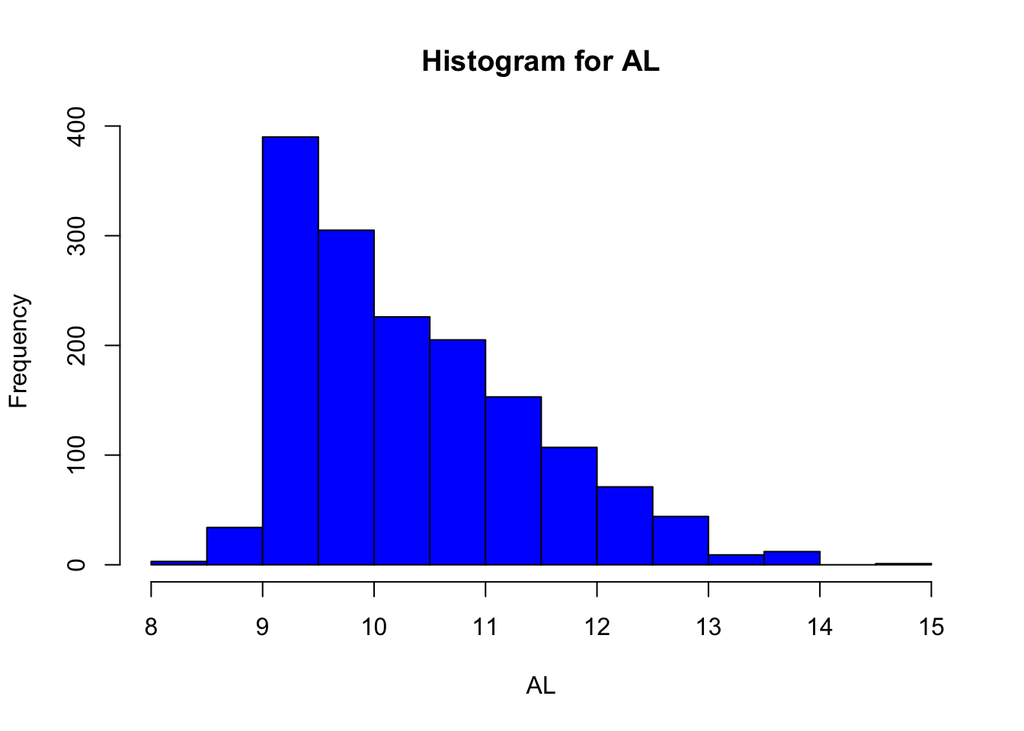

```r
for (column_name in colnames(df)) {
  if (class(df[[column_name]]) == "integer") {
    cat("Stem-and-Leaf Plot for", column_name, ":\n")
    stem(df[[column_name]])
    cat("\n")
  } else {
    #cat("Histogram for", column_name, ":\n")
    hist(df[[column_name]], main = paste("Histogram for", column_name),
         xlab = column_name, ylab = "Frequency", col = "blue", border = "black")
    cat("\n")
  }
}
```

### Problem 1b

For each variable, plot the distribution using a box-and-whisker plot. Are there any significant outliers? Note: some variables have comparable scales, while others do not

**Answer** Variables with significant outliers - RS - CH - SU - PH - FA

```r
for (column_name in colnames(df)) {
  min_val <- min(df[[column_name]], na.rm = TRUE)
  max_val <- max(df[[column_name]], na.rm = TRUE)
  cat(column_name, "Min:", min_val, "Max:", max_val, "\n")
}
```

```
## QA Min: 3 Max: 8
## FA Min: 4.6 Max: 15.9
## VA Min: 0.12 Max: 1.58
## CA Min: 0 Max: 1
## RS Min: 0.9 Max: 15.5
## CH Min: 0.012 Max: 0.611
## FS Min: 1 Max: 72
## SD Min: 6 Max: 289
## DE Min: 0.99007 Max: 1.00369
## PH Min: 0.01 Max: 8.23
## SU Min: 0.33 Max: 2
## AL Min: 8.4 Max: 14.9
```

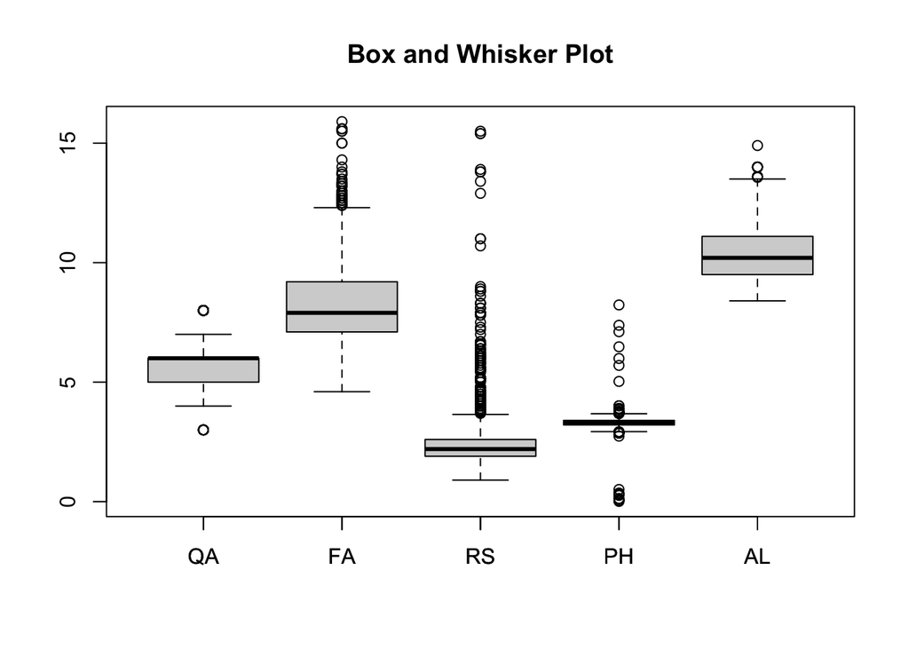

```r
# QA, FA, RS, PH, AL

selected_columns <- c("QA", "FA", "RS", "PH", "AL")

# Create a box and whisker plot for the selected columns
boxplot(df[, selected_columns], names = selected_columns, main = "Box and Whisker Plot")

# Add labels to the x-axis and y-axis
axis(1, at = 1:length(selected_columns), labels = selected_columns)
```

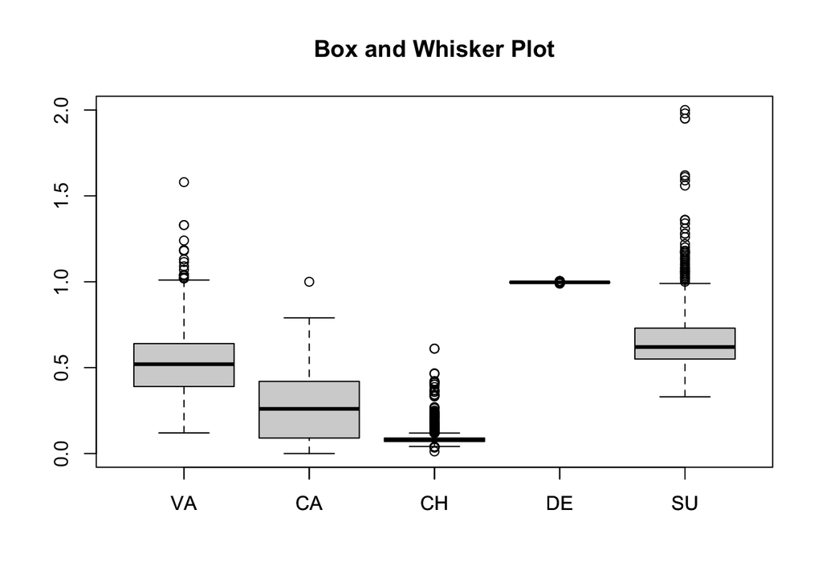

```r
# VA, CA, CH, DE, SU
selected_columns <- c("VA", "CA", "CH", "DE", "SU")

# Create a box and whisker plot for the selected columns
boxplot(df[, selected_columns], names = selected_columns, main = "Box and Whisker Plot")

# Add labels to the x-axis and y-axis
axis(1, at = 1:length(selected_columns), labels = selected_columns)
```

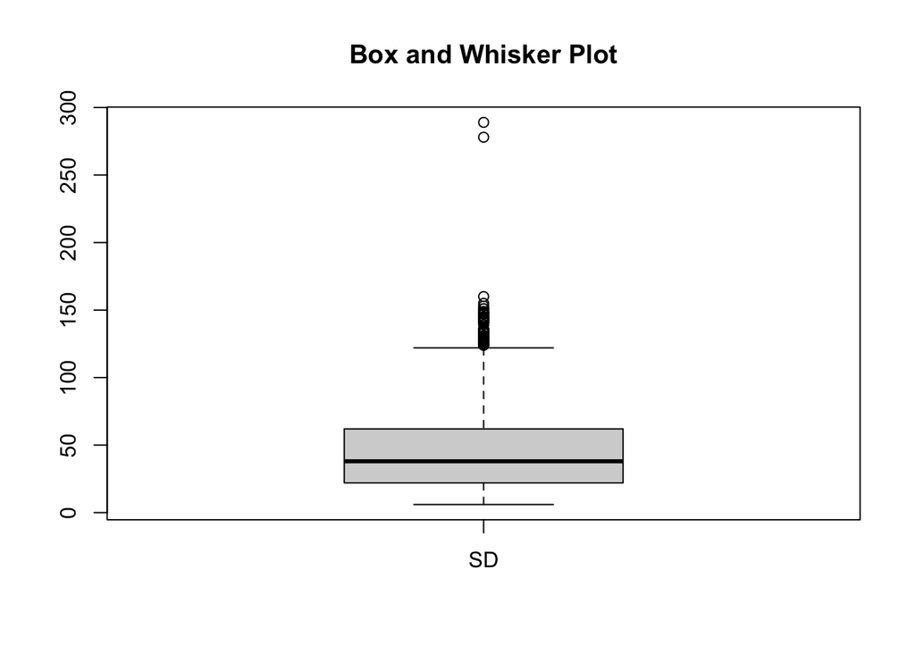

```r
# SD
selected_columns <- c("SD")

# Create a box and whisker plot for the selected columns
boxplot(df[, selected_columns], names = selected_columns, main = "Box and Whisker Plot")

# Add labels to the x-axis and y-axis
axis(1, at = 1:length(selected_columns), labels = selected_columns)
```

### Problem 1c

For each variable, compute the skewness and kurtotsis. Which variables are skewed left, skewed right, and not significantly skewed? Which are mesokurtic (kurtosis around 3), leptokurtic (kurtosis > 3, fat tails), and platykurtic (kurtosis < 3, thin tails)?

```r
# Install and load the 'e1071' package
if (!requireNamespace("e1071", quietly = TRUE)) {
  install.packages("e1071")
}
library(e1071)

# Function to classify skewness
classify_skewness <- function(skewness_value) {
  if (is.na(skewness_value)) {
    return("Undefined (Missing Value)")
  } else if (abs(skewness_value) < 0.5) {
    return("Not significantly skewed")
  } else if (skewness_value < -0.5) {
    return("Skewed left")
  } else if (skewness_value > 0.5) {
    return("Skewed right")
  } else {
    return("Undefined")
  }
}

# Function to classify kurtosis
classify_kurtosis <- function(kurtosis_value) {
  if (is.na(kurtosis_value)) {
    return("Undefined (Missing Value)")
  } else if (abs(kurtosis_value - 3) < 1) {
    return("Mesokurtic")
  } else if (kurtosis_value > 3) {
    return("Leptokurtic")
  } else if (kurtosis_value < 3) {
    return("Platykurtic")
  } else {
    return("Undefined")
  }
}


# Calculate skewness and kurtosis for each variable, ignoring missing values
skewness_values <- sapply(df, skewness, type = 1)  # Type 1 for Pearson's skewness
kurtosis_values <- sapply(df, kurtosis, type = 1)  # Type 1 for Pearson's kurtosis

# Classify skewness and kurtosis for each variable
skewness_classification <- sapply(skewness_values, classify_skewness)
kurtosis_classification <- sapply(kurtosis_values, classify_kurtosis)

# Print the classification for each variable
for (i in 1:length(skewness_classification)) {
  cat("Variable:", names(skewness_classification)[i], "\n")
  cat("Skewness:", skewness_values[i], "\n")
  cat("Kurtosis:", kurtosis_values[i], "\n")
  cat("Skewness Classification:", skewness_classification[i], "\n")
  cat("Kurtosis Classification:", kurtosis_classification[i], "\n")
  cat("-------------------------------------\n")
}
```

```
## Variable: QA
## Skewness: 0.2089778
## Kurtosis: 0.2795533
## Skewness Classification: Not significantly skewed
## Kurtosis Classification: Platykurtic
## -------------------------------------
## Variable: FA
## Skewness: 0.9850544
## Kurtosis: 1.135989
## Skewness Classification: Skewed right
## Kurtosis Classification: Platykurtic
## -------------------------------------
## Variable: VA
## Skewness: 0.6719443
## Kurtosis: 1.24426
## Skewness Classification: Skewed right
## Kurtosis Classification: Platykurtic
## -------------------------------------
## Variable: CA
## Skewness: 0.3184165
## Kurtosis: -0.7958335
## Skewness Classification: Not significantly skewed
## Kurtosis Classification: Platykurtic
## -------------------------------------
## Variable: RS
## Skewness: 4.537677
## Kurtosis: 28.38193
## Skewness Classification: Skewed right
## Kurtosis Classification: Leptokurtic
## -------------------------------------
## Variable: CH
## Skewness: 5.711645
## Kurtosis: 42.33712
## Skewness Classification: Skewed right
## Kurtosis Classification: Leptokurtic
## -------------------------------------
## Variable: FS
## Skewness: 1.250388
## Kurtosis: 2.051583
## Skewness Classification: Skewed right
```

[output cut: 17 more lines]

```
## Skewness Classification: Not significantly skewed
## Kurtosis Classification: Leptokurtic
## -------------------------------------
## Variable: SU
## Skewness: 2.455509
## Kurtosis: 11.96519
## Skewness Classification: Skewed right
## Kurtosis Classification: Leptokurtic
## -------------------------------------
## Variable: AL
## Skewness: 0.8597241
## Kurtosis: 0.1984169
## Skewness Classification: Skewed right
## Kurtosis Classification: Platykurtic
## -------------------------------------
```

### Problem 1d

For each variable, display the Q-Q plot. Do they confirm your observations from previous parts of Problem 1?

**Ans**

Yes, the below Q-Q plots confirm the observations from Problem 1. The plots for RS, CH, SU, PH and FA clearly don’t follow the 45 degree line and hence are subjected to signficant outliers.

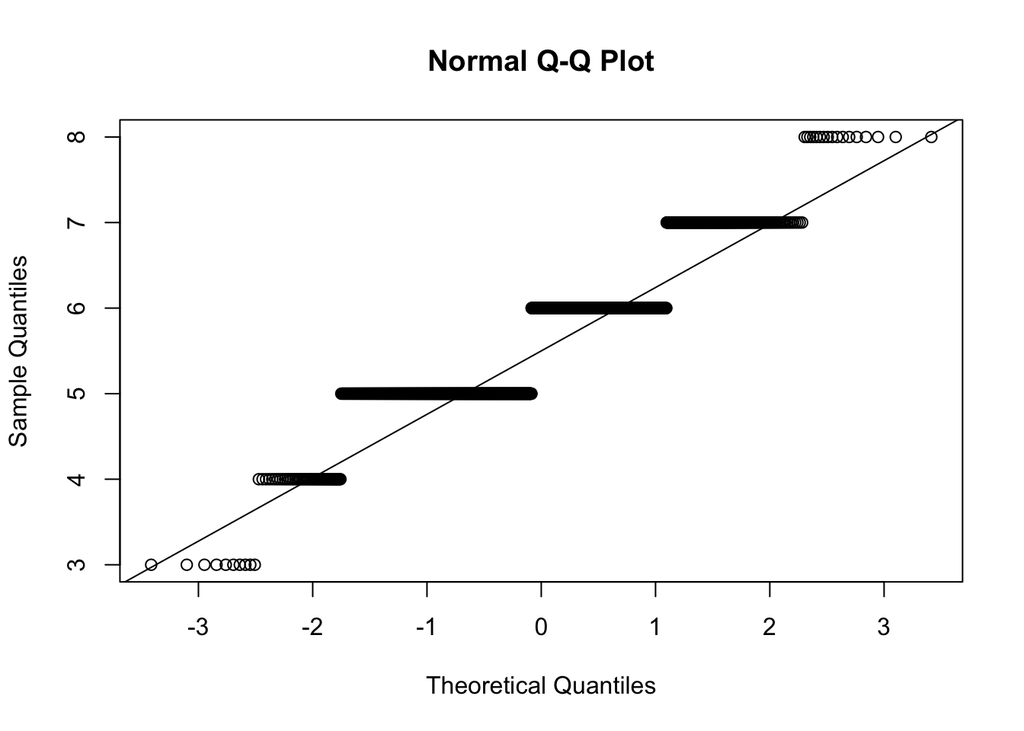

```
## Q-Q Plot for Variable: QA
```

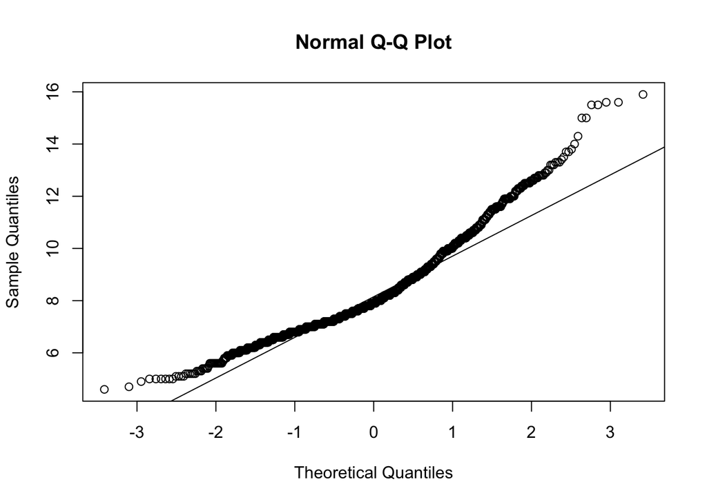

```
## Q-Q Plot for Variable: FA
```

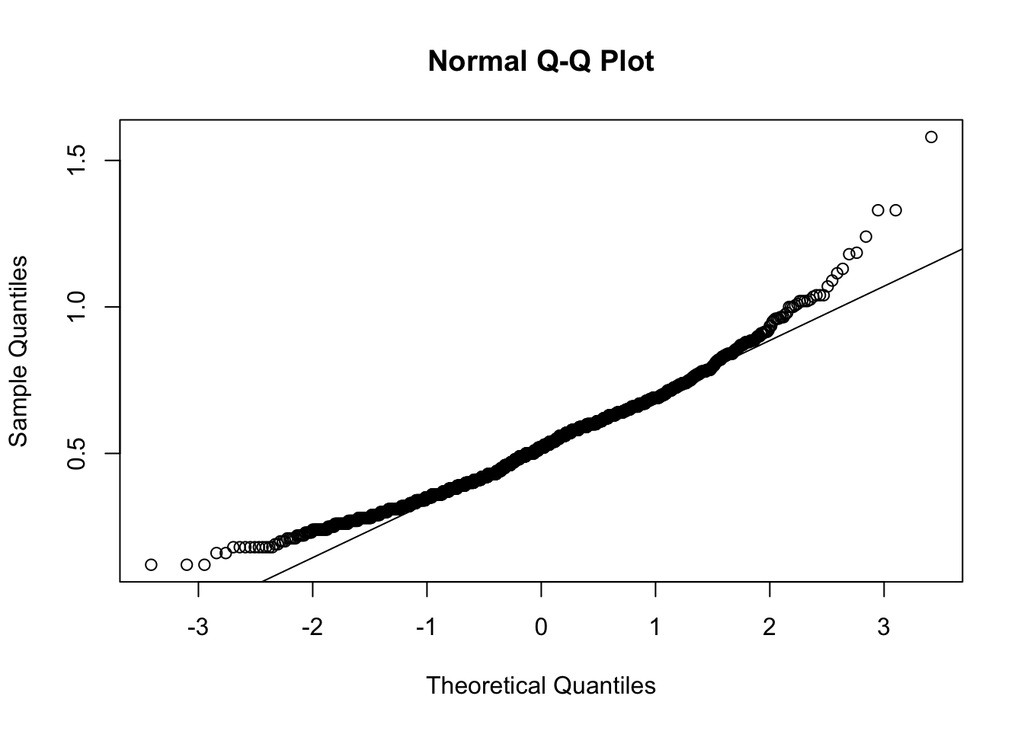

```
## Q-Q Plot for Variable: VA
```

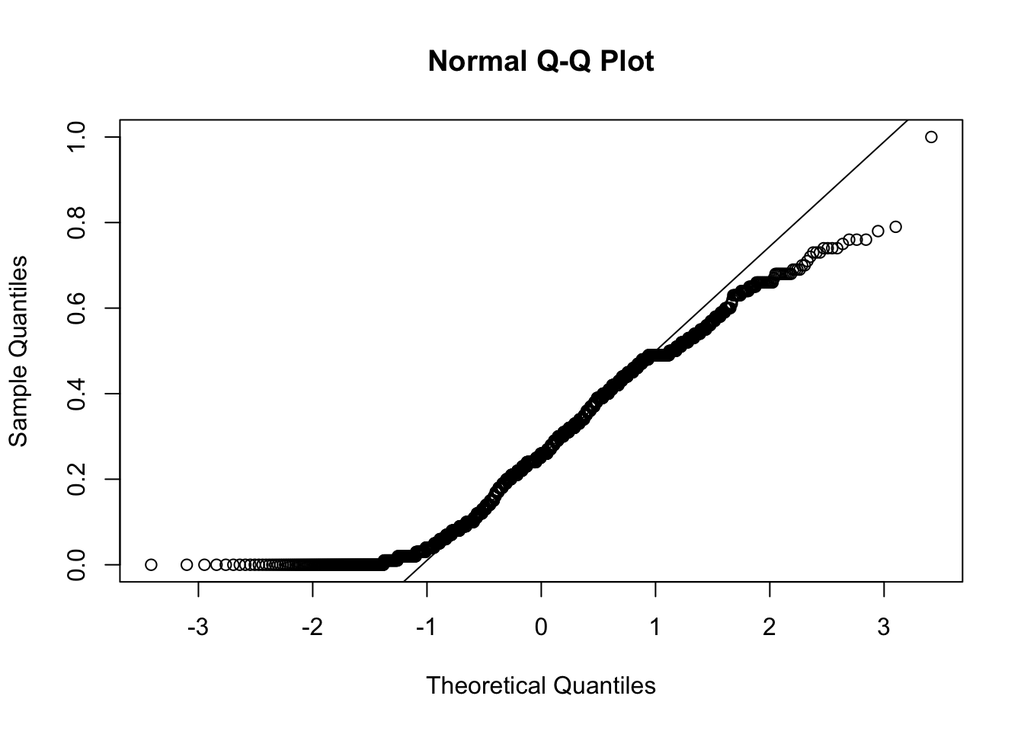

```
## Q-Q Plot for Variable: CA
```

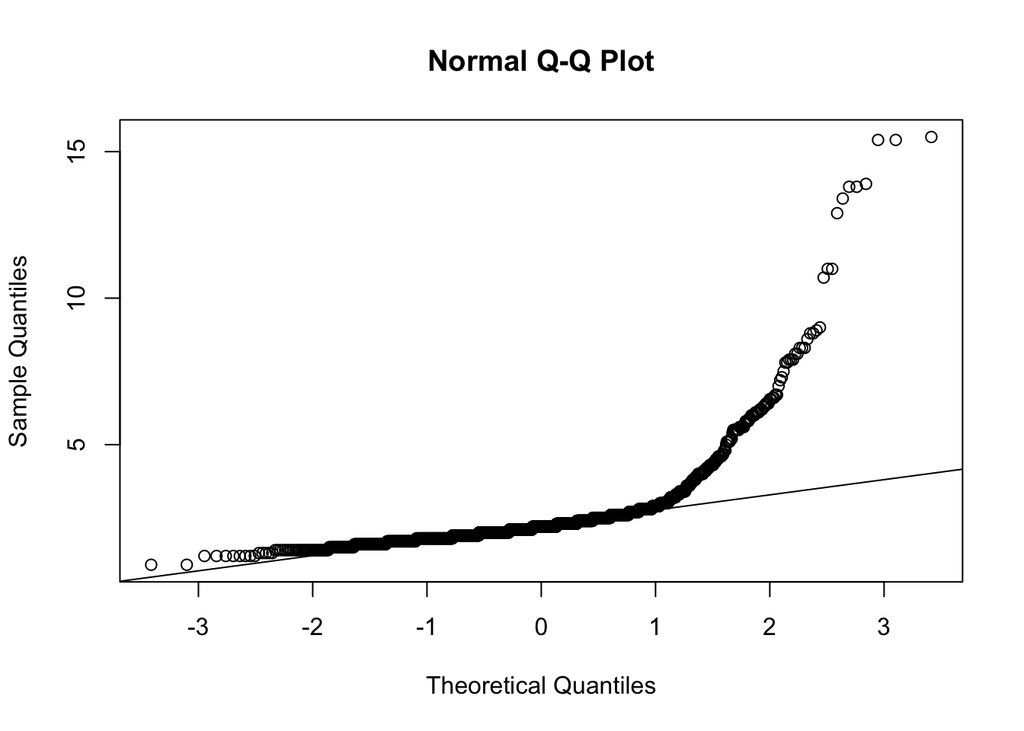

```
## Q-Q Plot for Variable: RS
```

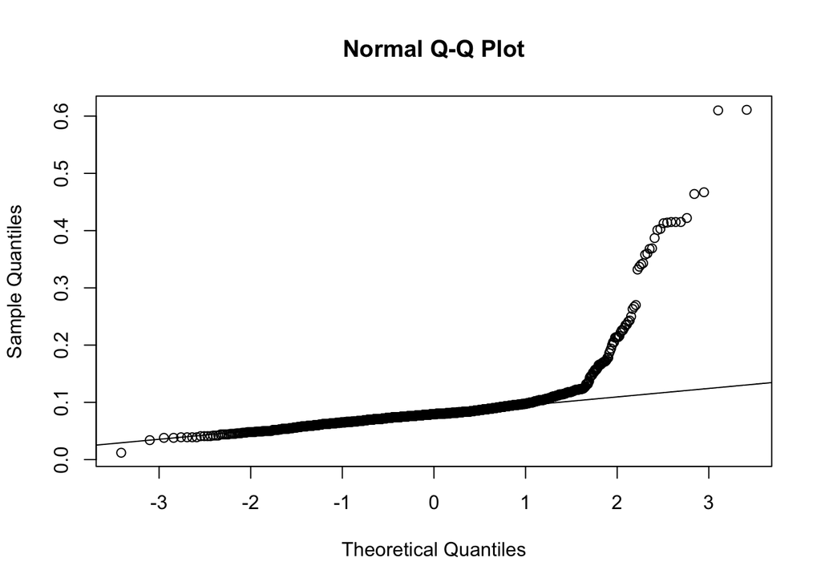

```
## Q-Q Plot for Variable: CH
```

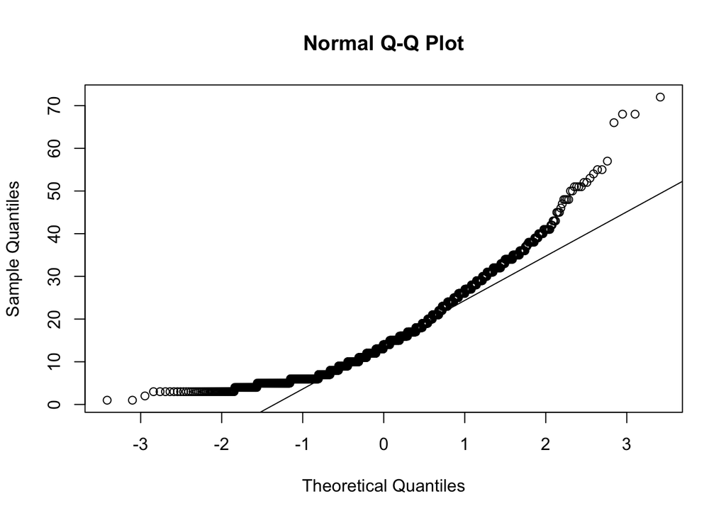

```
## Q-Q Plot for Variable: FS
```

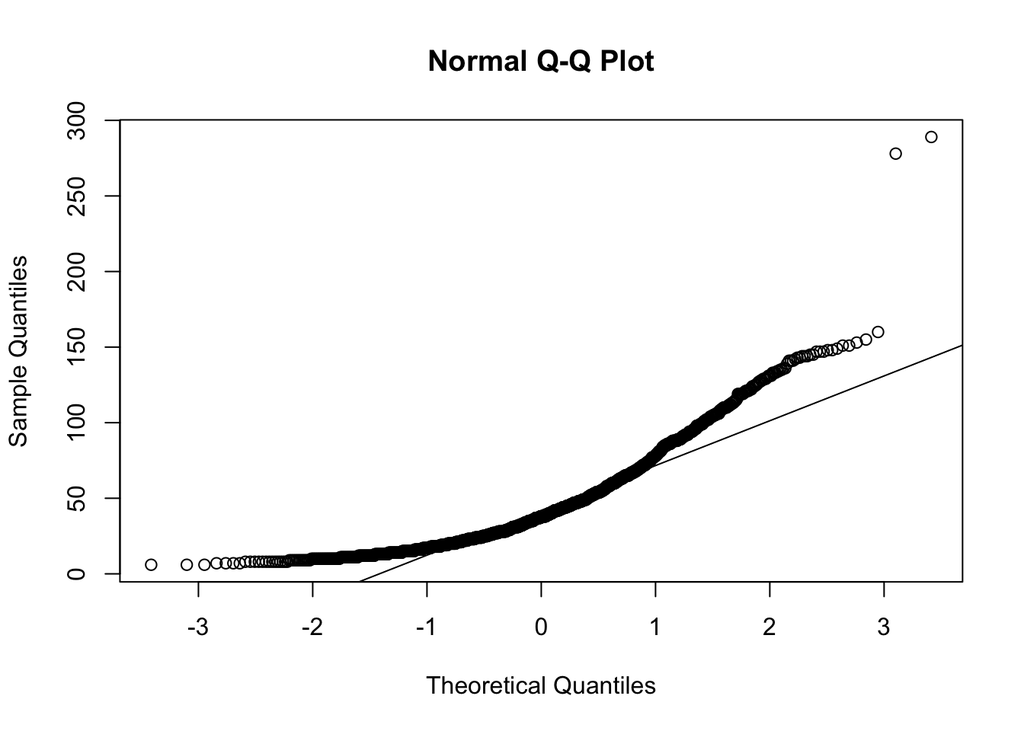

```
## Q-Q Plot for Variable: SD
```

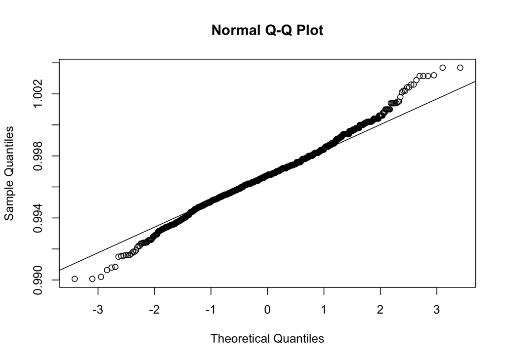

```
## Q-Q Plot for Variable: DE
```

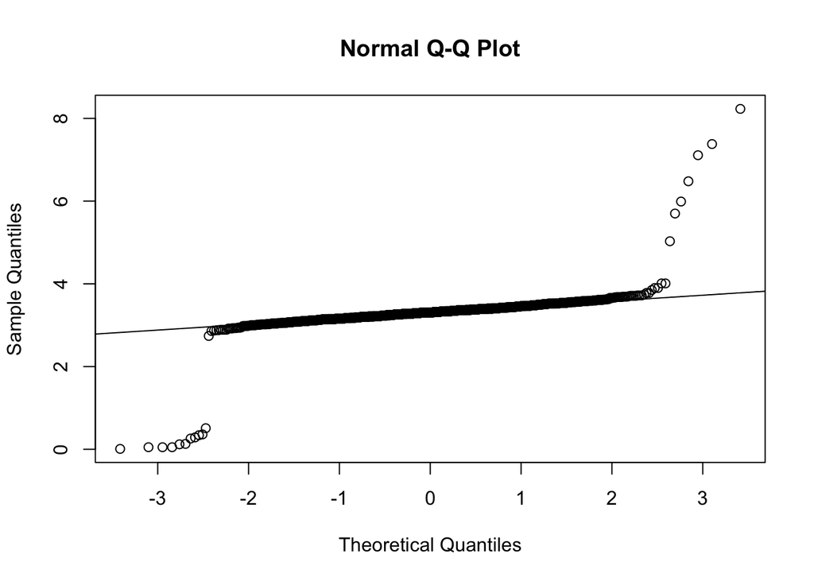

```
## Q-Q Plot for Variable: PH
```

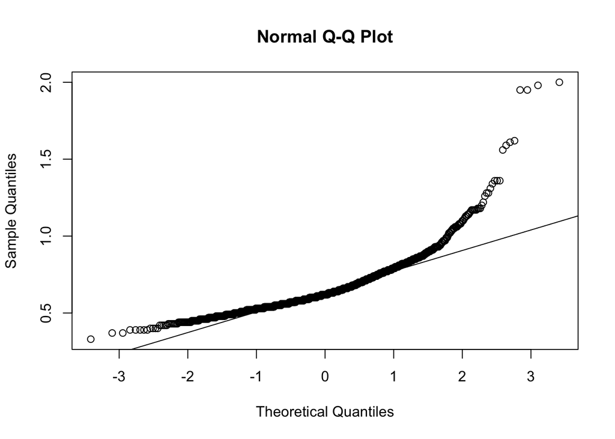

```
## Q-Q Plot for Variable: SU
```

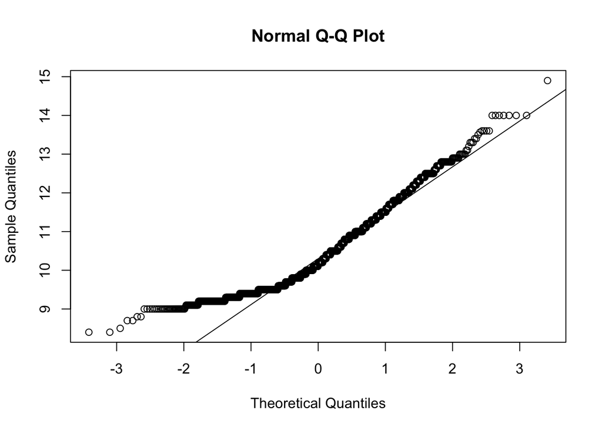

```
## Q-Q Plot for Variable: AL
```

```r
# Create a sample dataframe (replace this with your actual dataframe)
# Assuming you have a dataframe called 'df' with 11 variables

# Function to create and display Q-Q plots for a given variable
create_and_display_qq_plot <- function(variable, variable_name) {
  # Remove NA values
  variable <- na.omit(variable)

  # Create Q-Q plot
  qqnorm(variable)
  qqline(variable)

  # Print a message
  cat("Q-Q Plot for Variable:", variable_name, "\n")

  # Display the plot (do not save)
  plot.new()
}

# Loop through each variable in the dataframe and create/display Q-Q plots
for (variable_name in colnames(df)) {
  create_and_display_qq_plot(df[, variable_name], variable_name)
}
```

## Problem 2

Your goal is use the redwine.txt dataset (the same dataset evaluated in Problem 1) to predict the wine quality given the other variables. You will use various methods to fill missing values.

```r
df = read.table('redwine.txt', header=TRUE)
head(df)
```

```
##   QA   FA   VA   CA  RS    CH FS SD     DE   PH   SU  AL
## 1  5  7.4 0.70 0.00 1.9 0.076 11 34 0.9978 3.51 0.56 9.4
## 2  5  7.8 0.88 0.00 2.6 0.098 25 67 0.9968 3.20 0.68 9.8
## 3  5  7.8 0.76 0.04 2.3 0.092 15 54 0.9970 3.26 0.65 9.8
## 4  6 11.2 0.28 0.56 1.9 0.075 17 60 0.9980 3.16 0.58 9.8
## 5  5  7.4 0.70 0.00 1.9 0.076 11 34 0.9978 3.51 0.56 9.4
## 6  5  7.4 0.66 0.00 1.8 0.075 13 40 0.9978 3.51 0.56 9.4
```

### Problem 2a

Use is.na to determine which variables have missing values. How many missing values are there in each variable (Hint: use colSums)? How many samples have missing values (Hint: use rowSums)?

```r
# Determine which variables have missing values and count them
missing_per_variable <- colSums(is.na(df))

# Count the number of samples with missing values
samples_with_missing_values <- sum(rowSums(is.na(df)) > 0)

# Print the number of missing values in each variable
cat("Missing values per variable:\n")
```

```
## Missing values per variable:
```

```r
print(missing_per_variable)
```

```
## QA FA VA CA RS CH FS SD DE PH SU AL
##  0  0  0  0 22  0  0 17  0  0  0  0
```

```r
# Print the number of samples with missing values
cat("\nNumber of samples with missing values:", samples_with_missing_values, "\n")
```

```
##
## Number of samples with missing values: 39
```

## Problem 2b

```r
library(caret)
# Load the dataset
redwine_data <- read.table("redwine.txt", header = TRUE, sep = "")

set.seed(1)
num_folds = 5
# Set up repeated k-fold cross-validation
folds <- createFolds(redwine_data$QA, k = num_folds)
```

```r
# Function to impute missing values, if any
impute_missing_values_with_random <- function(data) {
  for(i in 1:ncol(data)){

    na_indices <- which(is.na(data[, i]))
    non_na_indices <- which(!is.na(data[, i]))

    data[na_indices, i] <- sample(data[non_na_indices, i], length(na_indices), replace = TRUE)
  }
  return(data)
}

# Custom function to calculate MSE
calculate_mse <- function(actual, predicted) {
  sum((actual - predicted)^2) / length(actual)
}
```

```r
library(caret)
set.seed(1) # for reproducibility

redwine_data <- read.table("redwine.txt", header = TRUE, sep = "")

# Initialize vectors to store the MSE for each fold
mse_train <- numeric(num_folds)
mse_test <- numeric(num_folds)

# Loop over each fold
for(i in 1:num_folds){
  # Split the data into training and test sets
  curr_fold = folds[[i]]
  train_data <- redwine_data[-curr_fold, ]
  test_data <- redwine_data[curr_fold, ]

  #print(paste("Training Set Size: ", nrow(train_data)))
  #print(paste("Test Set Size: ", nrow(test_data)))

  # Impute Missing Values in the dataset
  train_data <- impute_missing_values_with_random(train_data)
  test_data <- impute_missing_values_with_random(test_data)
  # Train the linear regression model
  model <- lm(QA ~ ., data = train_data)

  # Predict on training and test data
  predictions_train <- predict(model, train_data)
  predictions_test <- predict(model, test_data)

  # Compute MSE for training and test sets
  mse_train[i] <- calculate_mse(train_data$QA, predictions_train)
  mse_test[i] <- calculate_mse(test_data$QA, predictions_test)
}

# Output the average MSE for both training and test datasets
average_mse_train <- mean(mse_train)
average_mse_test <- mean(mse_test)

print(paste("Average MSE for Training Dataset: ", average_mse_train))
```

```
## [1] "Average MSE for Training Dataset:  0.417443866616441"
```

```r
print(paste("Average MSE for Testing Dataset: ", average_mse_test))
```

```
## [1] "Average MSE for Testing Dataset:  0.422877102049628"
```

## Problem 2c

Repeat the process in Problem 2b, using the most common value method to fill missing values. Use the same CV folds.

```r
# Function to calculate the mode (most common value)
calculate_mode <- function(x) {
  # Create a frequency table of the non-NA values
  freq_table <- table(na.omit(x))
  # Return the value (name) of the max frequency (non-NA)
  as.numeric(names(freq_table)[which.max(freq_table)])
}

impute_missing_values_with_mode <- function(data) {
  for(i in 1:ncol(data)){
    # Calculate mode for the current column
    mode_value <- calculate_mode(data[[i]])
    # Replace NA values with the mode value
    data[is.na(data[[i]]), i] <- mode_value
  }
  return(data)
}
```

```r
library(caret)
set.seed(1) # for reproducibility

# Load the dataset
redwine_data <- read.table("redwine.txt", header = TRUE, sep = "")

# Initialize vectors to store the MSE for each fold
mse_train <- numeric(num_folds)
mse_test <- numeric(num_folds)

# Loop over each fold
for(i in 1:num_folds){
  # Split the data into training and test sets
  curr_fold = folds[[i]]
  train_data <- redwine_data[-curr_fold, ]
  test_data <- redwine_data[curr_fold, ]

  #print(paste("Training Set Size: ", nrow(train_data)))
  #print(paste("Test Set Size: ", nrow(test_data)))

  # Impute Missing Values in the dataset
  train_data <- impute_missing_values_with_mode(train_data)
  test_data <- impute_missing_values_with_mode(test_data)
  # Train the linear regression model
  model <- lm(QA ~ ., data = train_data)

  # Predict on training and test data
  predictions_train <- predict(model, train_data)
  predictions_test <- predict(model, test_data)

  # Compute MSE for training and test sets
  mse_train[i] <- calculate_mse(train_data$QA, predictions_train)
  mse_test[i] <- calculate_mse(test_data$QA, predictions_test)
}

# Output the average MSE for both training and test datasets
average_mse_train <- mean(mse_train)
average_mse_test <- mean(mse_test)

print(paste("Average MSE for Training Dataset: ", average_mse_train))
```

```
## [1] "Average MSE for Training Dataset:  0.41745109368723"
```

```r
print(paste("Average MSE for Testing Dataset: ", average_mse_test))
```

```
## [1] "Average MSE for Testing Dataset:  0.422722874149206"
```

## Problem 2d

Repeat the process in Problem 2b, using the average value method to fill missing values. Use the same CV folds

```r
impute_missing_values_with_mean <- function(data) {
  for(i in 1:ncol(data)){
    # Calculate mean for the current column, excluding NA values
    mean_value <- mean(data[[i]], na.rm = TRUE)
    # Replace NA values with the mean value
    data[is.na(data[[i]]), i] <- mean_value
  }
  return(data)
}
```

```r
library(caret)
set.seed(1) # for reproducibility

# Load the dataset
redwine_data <- read.table("redwine.txt", header = TRUE, sep = "")

# Initialize vectors to store the MSE for each fold
mse_train <- numeric(num_folds)
mse_test <- numeric(num_folds)

# Loop over each fold
for(i in 1:num_folds){
  # Split the data into training and test sets
  curr_fold = folds[[i]]
  train_data <- redwine_data[-curr_fold, ]
  test_data <- redwine_data[curr_fold, ]

  #print(paste("Training Set Size: ", nrow(train_data)))
  #print(paste("Test Set Size: ", nrow(test_data)))

  # Impute Missing Values in the dataset
  train_data <- impute_missing_values_with_mean(train_data)
  test_data <- impute_missing_values_with_mean(test_data)
  # Train the linear regression model
  model <- lm(QA ~ ., data = train_data)

  # Predict on training and test data
  predictions_train <- predict(model, train_data)
  predictions_test <- predict(model, test_data)

  # Compute MSE for training and test sets
  mse_train[i] <- calculate_mse(train_data$QA, predictions_train)
  mse_test[i] <- calculate_mse(test_data$QA, predictions_test)
}

# Output the average MSE for both training and test datasets
average_mse_train <- mean(mse_train)
average_mse_test <- mean(mse_test)

print(paste("Average MSE for Training Dataset: ", average_mse_train))
```

```
## [1] "Average MSE for Training Dataset:  0.417332721469906"
```

```r
print(paste("Average MSE for Testing Dataset: ", average_mse_test))
```

```
## [1] "Average MSE for Testing Dataset:  0.422626872579031"
```

## Problem 2e

Repeat the process in Problem 2b, using the k-NN method (with 5 nearest neighbors) to fill missing values. Use the same CV folds.

```r
library(caret)
library(VIM)
options( warn = -1 )
set.seed(1) # for reproducibility

# Load the dataset
redwine_data <- read.table("redwine.txt", header = TRUE, sep = "")

# Initialize vectors to store the MSE for each fold
mse_train <- numeric(num_folds)
mse_test <- numeric(num_folds)

# Loop over each fold
for(i in 1:num_folds){
  # Split the data into training and test sets
  curr_fold = folds[[i]]
  train_data <- redwine_data[-curr_fold, ]
  test_data <- redwine_data[curr_fold, ]

  #print(paste("Training Set Size: ", nrow(train_data)))
  #print(paste("Test Set Size: ", nrow(test_data)))

  # Impute Missing Values in the dataset
  train_data <- kNN(train_data, k=5)
  test_data <- kNN(test_data, k=5)

  # Train the linear regression model
  model <- lm(QA ~ ., data = train_data)

  # Predict on training and test data
  predictions_train <- predict(model, train_data)
  predictions_test <- predict(model, test_data)

  # Compute MSE for training and test sets
  mse_train[i] <- calculate_mse(train_data$QA, predictions_train)
  mse_test[i] <- calculate_mse(test_data$QA, predictions_test)
}

# Output the average MSE for both training and test datasets
average_mse_train <- mean(mse_train)
average_mse_test <- mean(mse_test)

print(paste("Average MSE for Training Dataset: ", average_mse_train))
```

```
## [1] "Average MSE for Training Dataset:  0.417088202649556"
```

```r
print(paste("Average MSE for Testing Dataset: ", average_mse_test))
```

```
## [1] "Average MSE for Testing Dataset:  0.423819362979535"
```

## Problem 2f

Repeat the process in Problem 2b, using the MICE method (with PMM) to fill missing values. Use the same CV folds.

```r
library(mice)
options( warn = -1 )
set.seed(1) # for reproducibility

# Load the dataset
redwine_data <- read.table("redwine.txt", header = TRUE, sep = "")

# Initialize vectors to store the MSE for each fold
mse_train <- numeric(num_folds)
mse_test <- numeric(num_folds)

# Loop over each fold
for(i in 1:num_folds){
  # Split the data into training and test sets
  curr_fold = folds[[i]]
  train_data <- redwine_data[-curr_fold, ]
  test_data <- redwine_data[curr_fold, ]

  #print(paste("Training Set Size: ", nrow(train_data)))
  #print(paste("Test Set Size: ", nrow(test_data)))

  # Impute Missing Values in the dataset
  train_data <- complete(mice(train_data, method = 'pmm', m = 1, maxit = 5, seed = 1),1)
  test_data <- complete(mice(test_data, method = 'pmm', m = 1, maxit = 5, seed = 1),1)

  # Train the linear regression model
  model <- lm(QA ~ ., data = train_data)

  # Predict on training and test data
  predictions_train <- predict(model, train_data)
  predictions_test <- predict(model, test_data)

  # Compute MSE for training and test sets
  mse_train[i] <- calculate_mse(train_data$QA, predictions_train)
  mse_test[i] <- calculate_mse(test_data$QA, predictions_test)
}
# Output the average MSE for both training and test datasets
average_mse_train <- mean(mse_train)
average_mse_test <- mean(mse_test)

print(paste("Average MSE for Training Dataset: ", average_mse_train))
```

```
## [1] "Average MSE for Training Dataset:  0.41769573280652"
```

```r
print(paste("Average MSE for Testing Dataset: ", average_mse_test))
```

```
## [1] "Average MSE for Testing Dataset:  0.422680152390376"
```

## Problem 2g

Repeat the process in Problem 2b, omitting samples with missing values. Use the same CV folds.

```r
library(caret)
set.seed(1) # for reproducibility

# Load the dataset
redwine_data <- read.table("redwine.txt", header = TRUE, sep = "")

# Initialize vectors to store the MSE for each fold
mse_train <- numeric(num_folds)
mse_test <- numeric(num_folds)

# Loop over each fold
for(i in 1:num_folds){
  # Split the data into training and test sets
  curr_fold = folds[[i]]
  train_data <- redwine_data[-curr_fold, ]
  test_data <- redwine_data[curr_fold, ]

  train_data <- na.omit(train_data)
  test_data <- na.omit(test_data)
  # Train the linear regression model
  model <- lm(QA ~ ., data = train_data)

  # Predict on training and test data
  predictions_train <- predict(model, train_data)
  predictions_test <- predict(model, test_data)

  # Compute MSE for training and test sets
  mse_train[i] <- calculate_mse(train_data$QA, predictions_train)
  mse_test[i] <- calculate_mse(test_data$QA, predictions_test)
}

# Output the average MSE for both training and test datasets
average_mse_train <- mean(mse_train)
average_mse_test <- mean(mse_test)

print(paste("Average MSE for Training Dataset: ", average_mse_train))
```

```
## [1] "Average MSE for Training Dataset:  0.420153643581382"
```

```r
print(paste("Average MSE for Testing Dataset: ", average_mse_test))
```

```
## [1] "Average MSE for Testing Dataset:  0.425801604734032"
```

## Problem 2h

Which method for handling missing values performs best? Why may this be?

## Explanation

Here all the imputaton techniques have worked quite similarly. There is no major differences in their performances. However Mean imputation has slightly better numbers but they are not very significant. This may be due to less missing values in the data, thats why all the algorithms seems to work more or less similarly